# Question

An [ellipse](https://en.wikipedia.org/wiki/Ellipse) is the set of points with a constant **sum** of distances from two foci.

A [hyperbola](https://en.wikipedia.org/wiki/Hyperbola) is the set of points with a constant **difference** of distances from two foci.

Let’s explore the idea that a hyberloa is a collection of points with a constant difference of distances. Consider the hyperbola below, centered at the origin with foci at $(-6.1,0)$ and $(6.1,0)$ and with vertices at $(-4.8,0)$ and $(4.8,0)$. We will begin by finding the distances (and their difference) from the foci to a vertex.

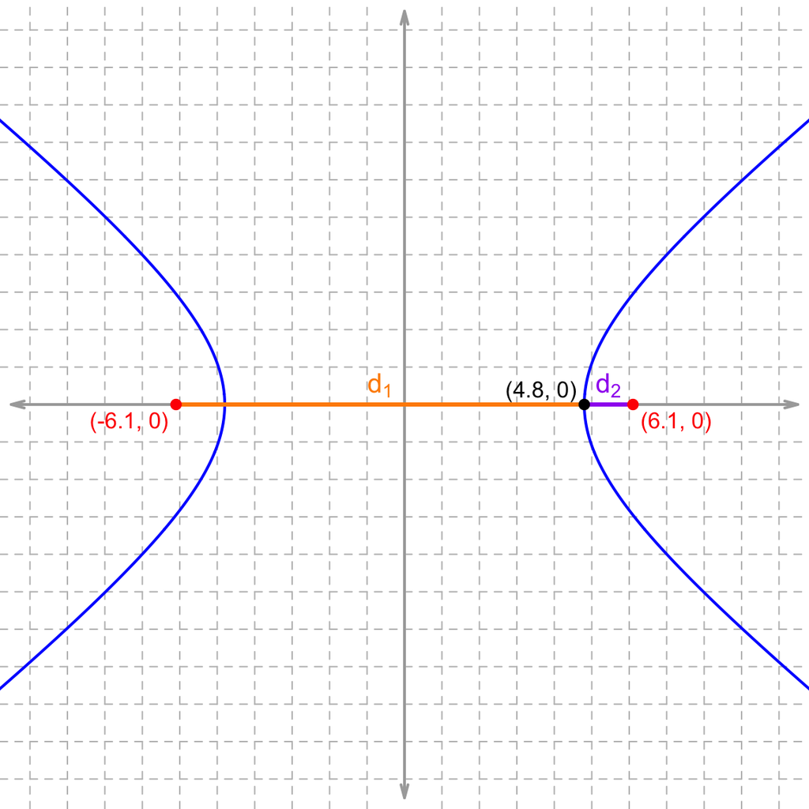

- Find the longer distance from a foci to a vertex. $d_1=$ ##ANSWER1##
- Find the shorter distance from a foci to a vertex. $d_2=$ ##ANSWER2##
- Find their difference. $d_1-d_2=$ ##ANSWER3##

Now let’s pick another point on the hyperbola: $(8.5,5.5)$

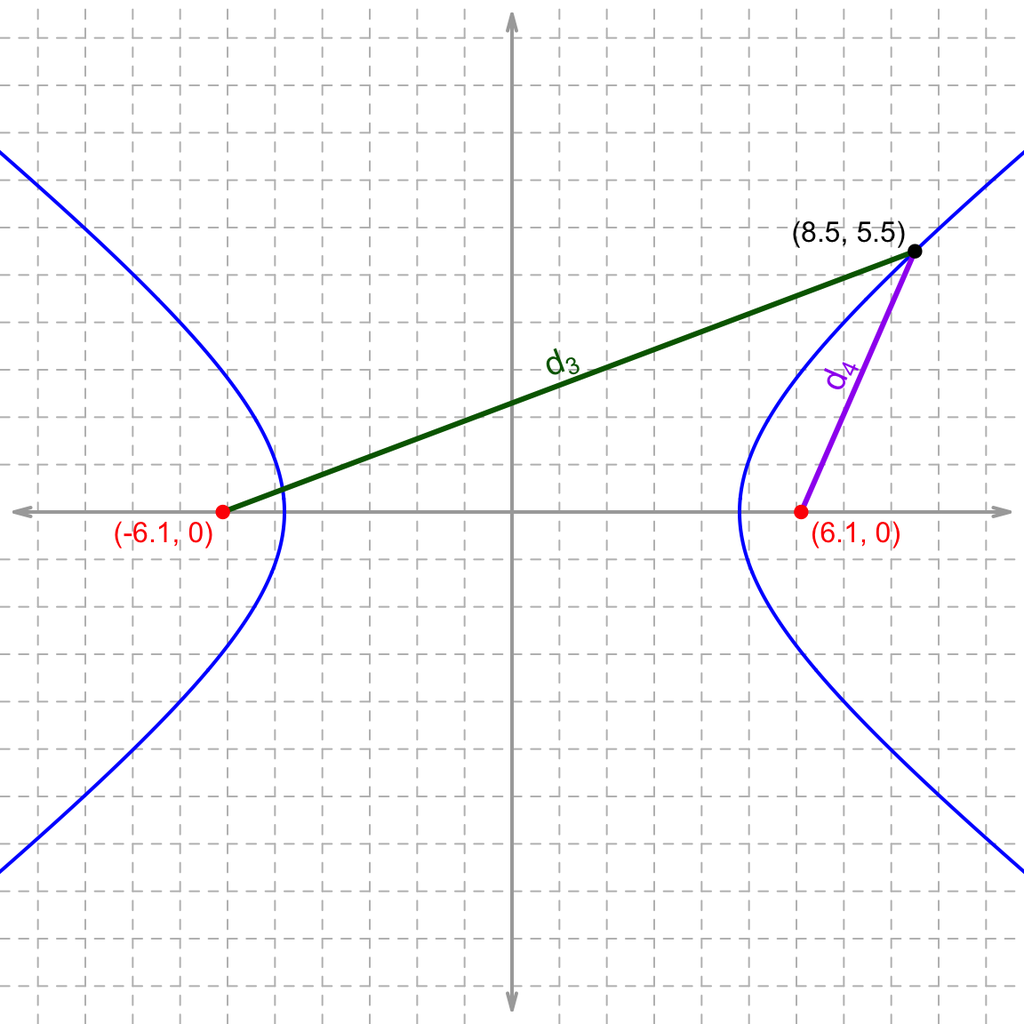

- Find the longer distance from a foci to the point. $d_3=$ ##ANSWER4##
- Find the shorter distance from a foci to the point. $d_4=$ ##ANSWER5##
- Find their difference. $d_3-d_4=$ ##ANSWER6##

## Answerlist

- 10.5
- 10.6
- 10.7
- 10.8
- 10.9
- 1
- 1.1
- 1.2
- 1.3
- 1.4
- 9.5
- 9.6
- 9.7
- 9.8
- 9.9
- 15.5
- 15.6
- 15.7
- 15.8
- 15.9
- 5.6
- 5.7
- 5.8
- 5.9
- 6
- 9.5
- 9.6
- 9.7
- 9.8
- 9.9

# Solution

The first two distances are both 1D distances, so they are found by simple addition/subtraction.

$$d_1 ~=~ 4.8-(-6.1) ~=~ 10.9$$
$$d_2 ~=~ 6.1-4.8 ~=~ 1.3$$
$$d_1-d2 ~=~ 9.6$$

The next distances ($d_3$ and $d_4$) require the 2D distance formula. Remember, distance formula is just Pythagorean Theorem. Make right triangles by using horizontal and vertical legs, and find the hypotenuse.

$$d_3 ~=~ \sqrt{(8.5-(-6.1))^2+5.5^2} ~=~
15.6$$
$$d_4 ~=~
\sqrt{(8.5-6.1)^2+5.5^2} ~=~ 6$$
$$d_3-d_4 ~=~ 9.6$$

Notice that $d_1-d_2=d_3-d_4$. The difference (of distances) remains constant as you move along a hyperbolic curve.

# Meta-information

extype: cloze exclozetype: schoice|schoice|schoice|schoice|schoice|schoice exsolution: 00001|00010|01000|01000|00001|01000 exname: hyperbola_intro